# group6_sprint1_cyberAttacks

## Sprint 1

### Project 1: Cyber Attacks

**Group 6:**  
Hamna Ashraf - 8826836  
John Prasad - 8976716  
Simardeep Singh - 8976948

### Required Libraries:

```python
import numpy as np
import pandas as pd
import matplotlib.pyplot as plt
import seaborn as sns
from sklearn.model_selection import train_test_split
from sklearn.ensemble import RandomForestClassifier
from sklearn.metrics import accuracy_score, classification_report, confusion_matrix
```

### Data Preprocessing:

```python
#read dataset
df_cyberattacks = pd.read_csv("./cybersecurity_attacks/cybersecurity_attacks.csv")
```

```python
pd.set_option('display.max_columns', None)
pd.set_option('display.max_rows', None)
df_cyberattacks.head()
```

|  | Timestamp | Source IP Address | Destination IP Address | Source Port | Destination Port | Protocol | Packet Length | Packet Type | Traffic Type | Payload Data | Malware Indicators | Anomaly Scores | Alerts/Warnings | Attack Type | Attack Signature | Action Taken | Severity Level | User Information | Device Information | Network Segment | Geo-location Data | Proxy Information | Firewall Logs | IDS/IPS Alerts | Log Source |
| --- | --- | --- | --- | --- | --- | --- | --- | --- | --- | --- | --- | --- | --- | --- | --- | --- | --- | --- | --- | --- | --- | --- | --- | --- | --- |
| 0 | 2023-05-30 06:33:58 | 103.216.15.12 | 84.9.164.252 | 31225 | 17616 | ICMP | 503 | Data | HTTP | Qui natus odio asperiores nam. Optio nobis ius... | IoC Detected | 28.67 | NaN | Malware | Known Pattern B | Logged | Low | Reyansh Dugal | Mozilla/5.0 (compatible; MSIE 8.0; Windows NT ... | Segment A | Jamshedpur, Sikkim | 150.9.97.135 | Log Data | NaN | Server |
| 1 | 2020-08-26 07:08:30 | 78.199.217.198 | 66.191.137.154 | 17245 | 48166 | ICMP | 1174 | Data | HTTP | Aperiam quos modi officiis veritatis rem. Omni... | IoC Detected | 51.50 | NaN | Malware | Known Pattern A | Blocked | Low | Sumer Rana | Mozilla/5.0 (compatible; MSIE 8.0; Windows NT ... | Segment B | Bilaspur, Nagaland | NaN | Log Data | NaN | Firewall |
| 2 | 2022-11-13 08:23:25 | 63.79.210.48 | 198.219.82.17 | 16811 | 53600 | UDP | 306 | Control | HTTP | Perferendis sapiente vitae soluta. Hic delectu... | IoC Detected | 87.42 | Alert Triggered | DDoS | Known Pattern B | Ignored | Low | Himmat Karpe | Mozilla/5.0 (compatible; MSIE 9.0; Windows NT ... | Segment C | Bokaro, Rajasthan | 114.133.48.179 | Log Data | Alert Data | Firewall |
| 3 | 2023-07-02 10:38:46 | 163.42.196.10 | 101.228.192.255 | 20018 | 32534 | UDP | 385 | Data | HTTP | Totam maxime beatae expedita explicabo porro l... | NaN | 15.79 | Alert Triggered | Malware | Known Pattern B | Blocked | Medium | Fateh Kibe | Mozilla/5.0 (Macintosh; PPC Mac OS X 10_11_5; ... | Segment B | Jaunpur, Rajasthan | NaN | NaN | Alert Data | Firewall |
| 4 | 2023-07-16 13:11:07 | 71.166.185.76 | 189.243.174.238 | 6131 | 26646 | TCP | 1462 | Data | DNS | Odit nesciunt dolorem nisi iste iusto. Animi v... | NaN | 0.52 | Alert Triggered | DDoS | Known Pattern B | Blocked | Low | Dhanush Chad | Mozilla/5.0 (compatible; MSIE 5.0; Windows NT ... | Segment C | Anantapur, Tripura | 149.6.110.119 | NaN | Alert Data | Firewall |

```python
df_cyberattacks.info()
```

```
<class 'pandas.core.frame.DataFrame'>
RangeIndex: 40000 entries, 0 to 39999
Data columns (total 25 columns):
 #   Column                  Non-Null Count  Dtype
---  ------                  --------------  -----
 0   Timestamp               40000 non-null  object
 1   Source IP Address       40000 non-null  object
 2   Destination IP Address  40000 non-null  object
 3   Source Port             40000 non-null  int64
 4   Destination Port        40000 non-null  int64
 5   Protocol                40000 non-null  object
 6   Packet Length           40000 non-null  int64
 7   Packet Type             40000 non-null  object
 8   Traffic Type            40000 non-null  object
 9   Payload Data            40000 non-null  object
```

[output cut: 17 more lines]

We can see that most columns have 40,000 non-null values except for a few columns. So there must be null values in our dataset.

```python
#check for null values
df_cyberattacks.isnull().sum()
```

```
Timestamp                     0
Source IP Address             0
Destination IP Address        0
Source Port                   0
Destination Port              0
Protocol                      0
Packet Length                 0
Packet Type                   0
Traffic Type                  0
Payload Data                  0
Malware Indicators        20000
Anomaly Scores                0
Alerts/Warnings           20067
Attack Type                   0
Attack Signature              0
Action Taken                  0
Severity Level                0
User Information              0
Device Information            0
Network Segment               0
Geo-location Data             0
Proxy Information         19851
Firewall Logs             19961
IDS/IPS Alerts            20050
Log Source                    0
dtype: int64
```

5 columns which includes 'Malware Indicators', 'Alerts/Warnings', 'Proxy Information', 'Firewall Logs' and 'IDS/IPS Alerts' have almost 20,000 null values i.e these columns have almost 50% of the data.

Let's start with the first column which is **Malware Indicators**:

```python
df_cyberattacks['Malware Indicators'].value_counts()
```

```
Malware Indicators
IoC Detected    20000
Name: count, dtype: int64
```

Malware Indicators are also known as Indicators of Compromise (IoCs).  
In the dataset, we only have the rows where IoC detected value exists, and rest of them are empty.  
This means that all values that have null must be those where IoC is not detected. So, let's fill the values accrodingly.

```python
df_cyberattacks['Malware Indicators'] = df_cyberattacks['Malware Indicators'].apply(lambda x: 'IoC not Detected' if x != 'IoC Detected' else x)
```

```python
df_cyberattacks.head()
```

|  | Timestamp | Source IP Address | Destination IP Address | Source Port | Destination Port | Protocol | Packet Length | Packet Type | Traffic Type | Payload Data | Malware Indicators | Anomaly Scores | Alerts/Warnings | Attack Type | Attack Signature | Action Taken | Severity Level | User Information | Device Information | Network Segment | Geo-location Data | Proxy Information | Firewall Logs | IDS/IPS Alerts | Log Source |
| --- | --- | --- | --- | --- | --- | --- | --- | --- | --- | --- | --- | --- | --- | --- | --- | --- | --- | --- | --- | --- | --- | --- | --- | --- | --- |
| 0 | 2023-05-30 06:33:58 | 103.216.15.12 | 84.9.164.252 | 31225 | 17616 | ICMP | 503 | Data | HTTP | Qui natus odio asperiores nam. Optio nobis ius... | IoC Detected | 28.67 | NaN | Malware | Known Pattern B | Logged | Low | Reyansh Dugal | Mozilla/5.0 (compatible; MSIE 8.0; Windows NT ... | Segment A | Jamshedpur, Sikkim | 150.9.97.135 | Log Data | NaN | Server |
| 1 | 2020-08-26 07:08:30 | 78.199.217.198 | 66.191.137.154 | 17245 | 48166 | ICMP | 1174 | Data | HTTP | Aperiam quos modi officiis veritatis rem. Omni... | IoC Detected | 51.50 | NaN | Malware | Known Pattern A | Blocked | Low | Sumer Rana | Mozilla/5.0 (compatible; MSIE 8.0; Windows NT ... | Segment B | Bilaspur, Nagaland | NaN | Log Data | NaN | Firewall |
| 2 | 2022-11-13 08:23:25 | 63.79.210.48 | 198.219.82.17 | 16811 | 53600 | UDP | 306 | Control | HTTP | Perferendis sapiente vitae soluta. Hic delectu... | IoC Detected | 87.42 | Alert Triggered | DDoS | Known Pattern B | Ignored | Low | Himmat Karpe | Mozilla/5.0 (compatible; MSIE 9.0; Windows NT ... | Segment C | Bokaro, Rajasthan | 114.133.48.179 | Log Data | Alert Data | Firewall |
| 3 | 2023-07-02 10:38:46 | 163.42.196.10 | 101.228.192.255 | 20018 | 32534 | UDP | 385 | Data | HTTP | Totam maxime beatae expedita explicabo porro l... | IoC not Detected | 15.79 | Alert Triggered | Malware | Known Pattern B | Blocked | Medium | Fateh Kibe | Mozilla/5.0 (Macintosh; PPC Mac OS X 10_11_5; ... | Segment B | Jaunpur, Rajasthan | NaN | NaN | Alert Data | Firewall |
| 4 | 2023-07-16 13:11:07 | 71.166.185.76 | 189.243.174.238 | 6131 | 26646 | TCP | 1462 | Data | DNS | Odit nesciunt dolorem nisi iste iusto. Animi v... | IoC not Detected | 0.52 | Alert Triggered | DDoS | Known Pattern B | Blocked | Low | Dhanush Chad | Mozilla/5.0 (compatible; MSIE 5.0; Windows NT ... | Segment C | Anantapur, Tripura | 149.6.110.119 | NaN | Alert Data | Firewall |

Now we see the changes made to the Malware Indicators column accordingly.

Next column is **Alerts/Warnings**:

```python
df_cyberattacks['Alerts/Warnings'].value_counts()
```

```
Alerts/Warnings
Alert Triggered    19933
Name: count, dtype: int64
```

In this column we can see that there is only 1 value which is alert triggered.  
This would probably mean that all those instances there the alert was triggered, the value 'Alert Triggered' is saved, others might have been left empty.  
One way to handle this is to fill all the other null values with 'Not triggered' and replace 'Alert Triggered' by 'Triggered'.

```python
df_cyberattacks['Alerts/Warnings'] = df_cyberattacks['Alerts/Warnings'].apply(lambda x: 'Triggered' if x == 'Alert Triggered' else 'Not Triggered')
```

```python
df_cyberattacks.head()
```

|  | Timestamp | Source IP Address | Destination IP Address | Source Port | Destination Port | Protocol | Packet Length | Packet Type | Traffic Type | Payload Data | Malware Indicators | Anomaly Scores | Alerts/Warnings | Attack Type | Attack Signature | Action Taken | Severity Level | User Information | Device Information | Network Segment | Geo-location Data | Proxy Information | Firewall Logs | IDS/IPS Alerts | Log Source |
| --- | --- | --- | --- | --- | --- | --- | --- | --- | --- | --- | --- | --- | --- | --- | --- | --- | --- | --- | --- | --- | --- | --- | --- | --- | --- |
| 0 | 2023-05-30 06:33:58 | 103.216.15.12 | 84.9.164.252 | 31225 | 17616 | ICMP | 503 | Data | HTTP | Qui natus odio asperiores nam. Optio nobis ius... | IoC Detected | 28.67 | Not Triggered | Malware | Known Pattern B | Logged | Low | Reyansh Dugal | Mozilla/5.0 (compatible; MSIE 8.0; Windows NT ... | Segment A | Jamshedpur, Sikkim | 150.9.97.135 | Log Data | NaN | Server |
| 1 | 2020-08-26 07:08:30 | 78.199.217.198 | 66.191.137.154 | 17245 | 48166 | ICMP | 1174 | Data | HTTP | Aperiam quos modi officiis veritatis rem. Omni... | IoC Detected | 51.50 | Not Triggered | Malware | Known Pattern A | Blocked | Low | Sumer Rana | Mozilla/5.0 (compatible; MSIE 8.0; Windows NT ... | Segment B | Bilaspur, Nagaland | NaN | Log Data | NaN | Firewall |
| 2 | 2022-11-13 08:23:25 | 63.79.210.48 | 198.219.82.17 | 16811 | 53600 | UDP | 306 | Control | HTTP | Perferendis sapiente vitae soluta. Hic delectu... | IoC Detected | 87.42 | Triggered | DDoS | Known Pattern B | Ignored | Low | Himmat Karpe | Mozilla/5.0 (compatible; MSIE 9.0; Windows NT ... | Segment C | Bokaro, Rajasthan | 114.133.48.179 | Log Data | Alert Data | Firewall |
| 3 | 2023-07-02 10:38:46 | 163.42.196.10 | 101.228.192.255 | 20018 | 32534 | UDP | 385 | Data | HTTP | Totam maxime beatae expedita explicabo porro l... | IoC not Detected | 15.79 | Triggered | Malware | Known Pattern B | Blocked | Medium | Fateh Kibe | Mozilla/5.0 (Macintosh; PPC Mac OS X 10_11_5; ... | Segment B | Jaunpur, Rajasthan | NaN | NaN | Alert Data | Firewall |
| 4 | 2023-07-16 13:11:07 | 71.166.185.76 | 189.243.174.238 | 6131 | 26646 | TCP | 1462 | Data | DNS | Odit nesciunt dolorem nisi iste iusto. Animi v... | IoC not Detected | 0.52 | Triggered | DDoS | Known Pattern B | Blocked | Low | Dhanush Chad | Mozilla/5.0 (compatible; MSIE 5.0; Windows NT ... | Segment C | Anantapur, Tripura | 149.6.110.119 | NaN | Alert Data | Firewall |

```python
df_cyberattacks['Alerts/Warnings'].value_counts()
```

```
Alerts/Warnings
Not Triggered    20067
Triggered        19933
Name: count, dtype: int64
```

Let's work on **Proxy Information**.  
The proxy information might not be available for instances where there are null values. So it's would be a better option to replace it with 'unknown'

```python
df_cyberattacks.fillna({'Proxy Information': 'unknown'}, inplace=True)
```

For the **Firewall Logs** column, null values can be replaced with 'No Log Data' and for column **IDS/IPS Alerts**, null values can replaced with 'No Alert Data'

```python
df_cyberattacks.fillna({'Firewall Logs': 'No Log Data'}, inplace=True)
```

```python
df_cyberattacks.fillna({'IDS/IPS Alerts': 'No Alert Data'}, inplace=True)
```

```python
df_cyberattacks.head()
```

|  | Timestamp | Source IP Address | Destination IP Address | Source Port | Destination Port | Protocol | Packet Length | Packet Type | Traffic Type | Payload Data | Malware Indicators | Anomaly Scores | Alerts/Warnings | Attack Type | Attack Signature | Action Taken | Severity Level | User Information | Device Information | Network Segment | Geo-location Data | Proxy Information | Firewall Logs | IDS/IPS Alerts | Log Source |
| --- | --- | --- | --- | --- | --- | --- | --- | --- | --- | --- | --- | --- | --- | --- | --- | --- | --- | --- | --- | --- | --- | --- | --- | --- | --- |
| 0 | 2023-05-30 06:33:58 | 103.216.15.12 | 84.9.164.252 | 31225 | 17616 | ICMP | 503 | Data | HTTP | Qui natus odio asperiores nam. Optio nobis ius... | IoC Detected | 28.67 | Not Triggered | Malware | Known Pattern B | Logged | Low | Reyansh Dugal | Mozilla/5.0 (compatible; MSIE 8.0; Windows NT ... | Segment A | Jamshedpur, Sikkim | 150.9.97.135 | Log Data | No Alert Data | Server |
| 1 | 2020-08-26 07:08:30 | 78.199.217.198 | 66.191.137.154 | 17245 | 48166 | ICMP | 1174 | Data | HTTP | Aperiam quos modi officiis veritatis rem. Omni... | IoC Detected | 51.50 | Not Triggered | Malware | Known Pattern A | Blocked | Low | Sumer Rana | Mozilla/5.0 (compatible; MSIE 8.0; Windows NT ... | Segment B | Bilaspur, Nagaland | unknown | Log Data | No Alert Data | Firewall |
| 2 | 2022-11-13 08:23:25 | 63.79.210.48 | 198.219.82.17 | 16811 | 53600 | UDP | 306 | Control | HTTP | Perferendis sapiente vitae soluta. Hic delectu... | IoC Detected | 87.42 | Triggered | DDoS | Known Pattern B | Ignored | Low | Himmat Karpe | Mozilla/5.0 (compatible; MSIE 9.0; Windows NT ... | Segment C | Bokaro, Rajasthan | 114.133.48.179 | Log Data | Alert Data | Firewall |
| 3 | 2023-07-02 10:38:46 | 163.42.196.10 | 101.228.192.255 | 20018 | 32534 | UDP | 385 | Data | HTTP | Totam maxime beatae expedita explicabo porro l... | IoC not Detected | 15.79 | Triggered | Malware | Known Pattern B | Blocked | Medium | Fateh Kibe | Mozilla/5.0 (Macintosh; PPC Mac OS X 10_11_5; ... | Segment B | Jaunpur, Rajasthan | unknown | No Log Data | Alert Data | Firewall |
| 4 | 2023-07-16 13:11:07 | 71.166.185.76 | 189.243.174.238 | 6131 | 26646 | TCP | 1462 | Data | DNS | Odit nesciunt dolorem nisi iste iusto. Animi v... | IoC not Detected | 0.52 | Triggered | DDoS | Known Pattern B | Blocked | Low | Dhanush Chad | Mozilla/5.0 (compatible; MSIE 5.0; Windows NT ... | Segment C | Anantapur, Tripura | 149.6.110.119 | No Log Data | Alert Data | Firewall |

```python
#Let's verify if all null values are removed:
df_cyberattacks.isnull().sum()
```

```
Timestamp                 0
Source IP Address         0
Destination IP Address    0
Source Port               0
Destination Port          0
Protocol                  0
Packet Length             0
Packet Type               0
Traffic Type              0
Payload Data              0
Malware Indicators        0
Anomaly Scores            0
Alerts/Warnings           0
Attack Type               0
Attack Signature          0
Action Taken              0
Severity Level            0
User Information          0
Device Information        0
Network Segment           0
Geo-location Data         0
Proxy Information         0
Firewall Logs             0
IDS/IPS Alerts            0
Log Source                0
dtype: int64
```

Now that there are no null values in the data, and our data appears to be clean, so let's start our EDA on this data.

### Exploratory Data Analysis (EDA)

```python
# Convert 'Timestamp' to datetime
df_cyberattacks['Timestamp'] = pd.to_datetime(df_cyberattacks['Timestamp'])

# Set 'Timestamp' as the index
df_cyberattacks.set_index('Timestamp', inplace=True)
```

We have set the Timestamp as the index. It will be useful as it is unique for every row in the dataset.

```
Average number of attacks per day: 28.99
```

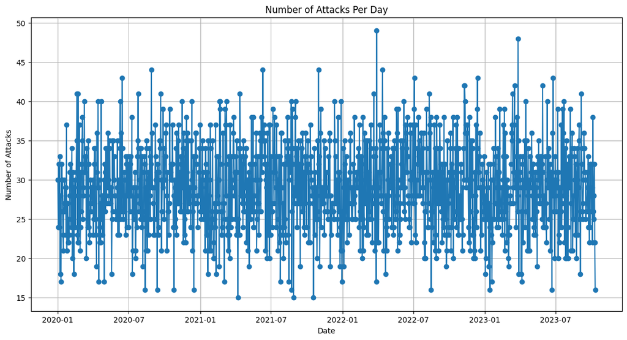

```python
# Resampling and plotting the number of attacks per day
attacks_per_day = df_cyberattacks.resample('D').size()

average_attacks_per_day = attacks_per_day.mean()
print(f'Average number of attacks per day: {average_attacks_per_day:.2f}')

plt.figure(figsize=(14, 7))
plt.plot(attacks_per_day, marker='o', linestyle='-')
plt.title('Number of Attacks Per Day')
plt.xlabel('Date')
plt.ylabel('Number of Attacks')
plt.grid(True)
plt.show()
```

We wanted to know the max number of attacks that occured in a single day.  
From this report, we can see that maximum number of attacks in a day happened in 2022, probably in the month of April - May where the total number of attacks in one day reached 49.

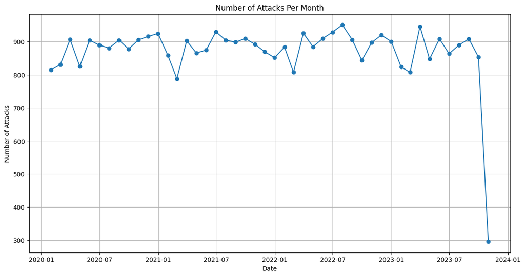

```python
# Resampling and plotting the number of attacks per month
attacks_per_month = df_cyberattacks.resample('ME').size()

plt.figure(figsize=(14, 7))
plt.plot(attacks_per_month, marker='o', linestyle='-')
plt.title('Number of Attacks Per Month')
plt.xlabel('Date')
plt.ylabel('Number of Attacks')
plt.grid(True)
plt.show()
```

Most attacks per month appear to have occured once in Aug 2022 and then April 2023 which reached 950 attacks.

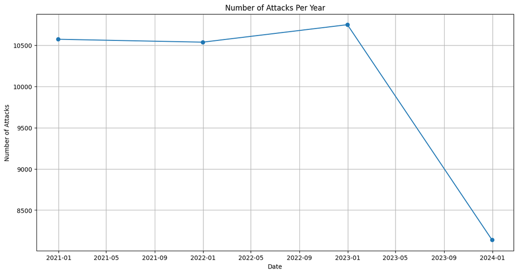

```python
# Resampling and plotting the number of attacks per year
attacks_per_year = df_cyberattacks.resample('YE').size()

plt.figure(figsize=(14, 7))
plt.plot(attacks_per_year, marker='o', linestyle='-')
plt.title('Number of Attacks Per Year')
plt.xlabel('Date')
plt.ylabel('Number of Attacks')
plt.grid(True)
plt.show()
```

According to this report, we can see that the most attacks was for the year 2022 that was almost 11,000.

```python
# Adding columns for day of week and hour
df_cyberattacks['Day of Week'] = df_cyberattacks.index.dayofweek
df_cyberattacks['Hour'] = df_cyberattacks.index.hour
```

```python
# Adding columns for year and month
df_cyberattacks['Year'] = df_cyberattacks.index.year
df_cyberattacks['Month'] = df_cyberattacks.index.month
```

```python
df_cyberattacks.head()
```

| Timestamp | Source IP Address | Destination IP Address | Source Port | Destination Port | Protocol | Packet Length | Packet Type | Traffic Type | Payload Data | Malware Indicators | Anomaly Scores | Alerts/Warnings | Attack Type | Attack Signature | Action Taken | Severity Level | User Information | Device Information | Network Segment | Geo-location Data | Proxy Information | Firewall Logs | IDS/IPS Alerts | Log Source | Day of Week | Hour | Year | Month |
| --- | --- | --- | --- | --- | --- | --- | --- | --- | --- | --- | --- | --- | --- | --- | --- | --- | --- | --- | --- | --- | --- | --- | --- | --- | --- | --- | --- | --- |
| 2023-05-30 06:33:58 | 103.216.15.12 | 84.9.164.252 | 31225 | 17616 | ICMP | 503 | Data | HTTP | Qui natus odio asperiores nam. Optio nobis ius... | IoC Detected | 28.67 | Not Triggered | Malware | Known Pattern B | Logged | Low | Reyansh Dugal | Mozilla/5.0 (compatible; MSIE 8.0; Windows NT ... | Segment A | Jamshedpur, Sikkim | 150.9.97.135 | Log Data | No Alert Data | Server | 1 | 6 | 2023 | 5 |
| 2020-08-26 07:08:30 | 78.199.217.198 | 66.191.137.154 | 17245 | 48166 | ICMP | 1174 | Data | HTTP | Aperiam quos modi officiis veritatis rem. Omni... | IoC Detected | 51.50 | Not Triggered | Malware | Known Pattern A | Blocked | Low | Sumer Rana | Mozilla/5.0 (compatible; MSIE 8.0; Windows NT ... | Segment B | Bilaspur, Nagaland | unknown | Log Data | No Alert Data | Firewall | 2 | 7 | 2020 | 8 |
| 2022-11-13 08:23:25 | 63.79.210.48 | 198.219.82.17 | 16811 | 53600 | UDP | 306 | Control | HTTP | Perferendis sapiente vitae soluta. Hic delectu... | IoC Detected | 87.42 | Triggered | DDoS | Known Pattern B | Ignored | Low | Himmat Karpe | Mozilla/5.0 (compatible; MSIE 9.0; Windows NT ... | Segment C | Bokaro, Rajasthan | 114.133.48.179 | Log Data | Alert Data | Firewall | 6 | 8 | 2022 | 11 |
| 2023-07-02 10:38:46 | 163.42.196.10 | 101.228.192.255 | 20018 | 32534 | UDP | 385 | Data | HTTP | Totam maxime beatae expedita explicabo porro l... | IoC not Detected | 15.79 | Triggered | Malware | Known Pattern B | Blocked | Medium | Fateh Kibe | Mozilla/5.0 (Macintosh; PPC Mac OS X 10_11_5; ... | Segment B | Jaunpur, Rajasthan | unknown | No Log Data | Alert Data | Firewall | 6 | 10 | 2023 | 7 |
| 2023-07-16 13:11:07 | 71.166.185.76 | 189.243.174.238 | 6131 | 26646 | TCP | 1462 | Data | DNS | Odit nesciunt dolorem nisi iste iusto. Animi v... | IoC not Detected | 0.52 | Triggered | DDoS | Known Pattern B | Blocked | Low | Dhanush Chad | Mozilla/5.0 (compatible; MSIE 5.0; Windows NT ... | Segment C | Anantapur, Tripura | 149.6.110.119 | No Log Data | Alert Data | Firewall | 6 | 13 | 2023 | 7 |

I noticed that for the year 2023, the data seem to be missing or not complete. Let's see till which month do we have the data

```python
df_2023 = df_cyberattacks[df_cyberattacks['Year'] == 2023]
```

```python
max_month_2023 = df_2023['Month'].max()
print("The maximum month for the year 2023 is:", max_month_2023)
```

```
The maximum month for the year 2023 is: 10
```

This shows us that in our dataset for the year 2023, we have data until October. No data exists onwards.

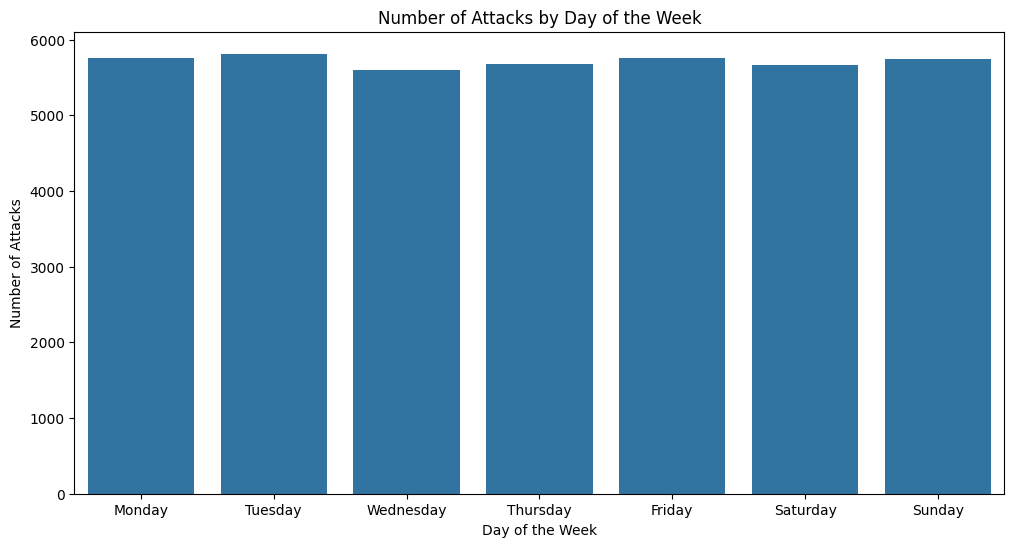

```python
# Grouping by day of the week
attacks_by_day = df_cyberattacks.groupby('Day of Week').size()

plt.figure(figsize=(12, 6))
sns.barplot(x=attacks_by_day.index, y=attacks_by_day.values)
plt.title('Number of Attacks by Day of the Week')
plt.xlabel('Day of the Week')
plt.ylabel('Number of Attacks')
plt.xticks(ticks=[0, 1, 2, 3, 4, 5, 6], labels=['Monday', 'Tuesday', 'Wednesday', 'Thursday', 'Friday', 'Saturday', 'Sunday'])
plt.show()
```

It can be seen that days of the week don't have any significant change in values. This means that number of attack are independent of the day of week.

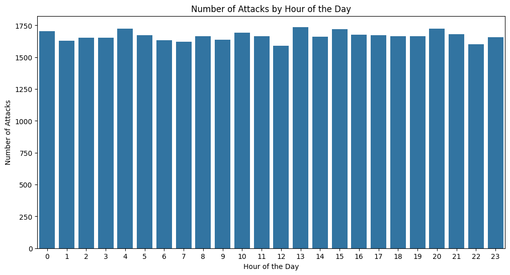

```python
# Grouping by hour of the day
attacks_by_hour = df_cyberattacks.groupby('Hour').size()

plt.figure(figsize=(12, 6))
sns.barplot(x=attacks_by_hour.index, y=attacks_by_hour.values)
plt.title('Number of Attacks by Hour of the Day')
plt.xlabel('Hour of the Day')
plt.ylabel('Number of Attacks')
plt.xticks(ticks=range(24), labels=[str(i) for i in range(24)])
plt.show()
```

The hour of day is also independent of the attacks.  
Now, let's see group the hour and attack type and see any significant difference.

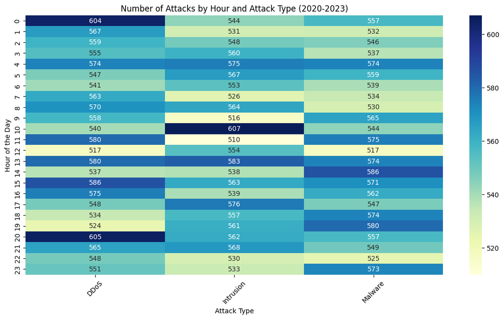

```python
attacks_by_hour_type = df_cyberattacks.groupby(['Hour', 'Attack Type']).size().unstack(fill_value=0)

plt.figure(figsize=(14, 7))
sns.heatmap(attacks_by_hour_type, annot=True, fmt="d", cmap="YlGnBu")
plt.title('Number of Attacks by Hour and Attack Type (2020-2023)')
plt.xlabel('Attack Type')
plt.ylabel('Hour of the Day')
plt.xticks(rotation=45)
plt.show()
```

The given report shows us that at timings 12am and 8pm, more than 600 DDoS attacks happened at each time.  
More than 600 Intrusion attacks occured at 10am.  
And almost 590 malware attacks occured at 2pm.

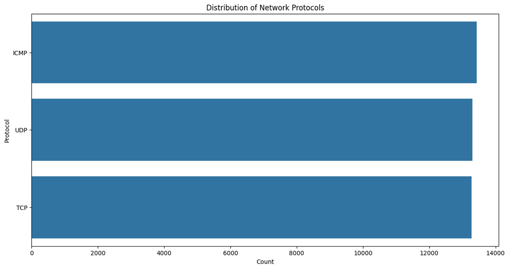

```python
plt.figure(figsize=(14, 7))
sns.countplot(y=df_cyberattacks['Protocol'], order=df_cyberattacks['Protocol'].value_counts().index)
plt.title('Distribution of Network Protocols')
plt.xlabel('Count')
plt.ylabel('Protocol')
plt.show()
```

In our dataset, we have equal distribution of Network Protocols which is almost 13,000 for each type.

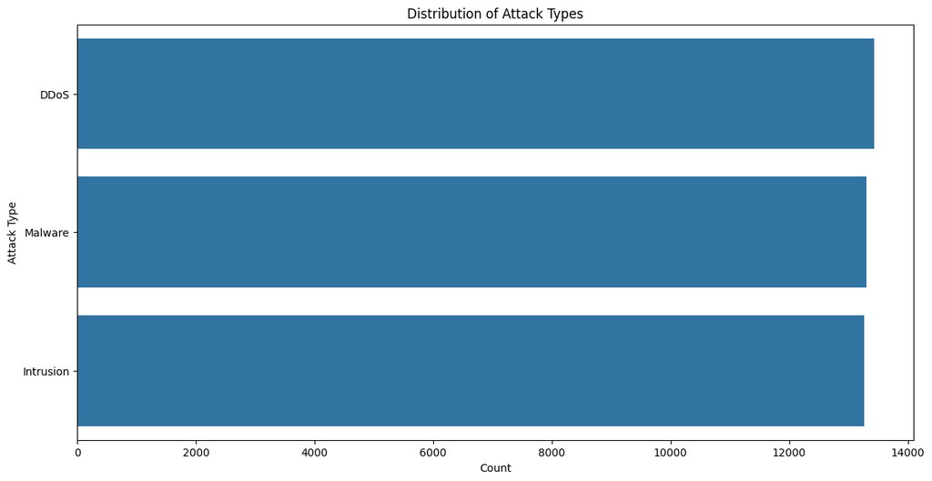

```python
plt.figure(figsize=(14, 7))
sns.countplot(y=df_cyberattacks['Attack Type'], order=df_cyberattacks['Attack Type'].value_counts().index)
plt.title('Distribution of Attack Types')
plt.xlabel('Count')
plt.ylabel('Attack Type')
plt.show()
```

The distribution of Attack types (DDoS, Malware, Intrusion) is also almost same.

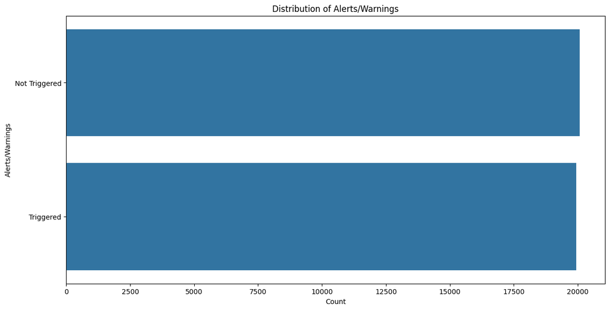

```python
plt.figure(figsize=(14, 7))
sns.countplot(y=df_cyberattacks['Alerts/Warnings'], order=df_cyberattacks['Alerts/Warnings'].value_counts().index)
plt.title('Distribution of Alerts/Warnings')
plt.xlabel('Count')
plt.ylabel('Alerts/Warnings')
plt.show()
```

This report shows us that only 50% of the times the alerts were triggered and for the rest there were no warnings/alerts. Let's see if attacks with high severity were missed.

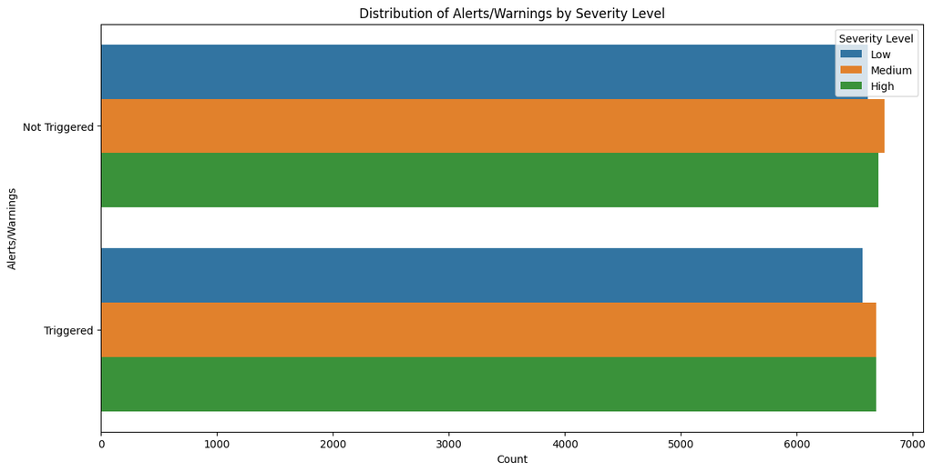

```python
plt.figure(figsize=(14, 7))
sns.countplot(y=df_cyberattacks['Alerts/Warnings'], hue=df_cyberattacks['Severity Level'],
              order=df_cyberattacks['Alerts/Warnings'].value_counts().index)

plt.title('Distribution of Alerts/Warnings by Severity Level')
plt.xlabel('Count')
plt.ylabel('Alerts/Warnings')
plt.legend(title='Severity Level', loc='upper right')
plt.show()
```

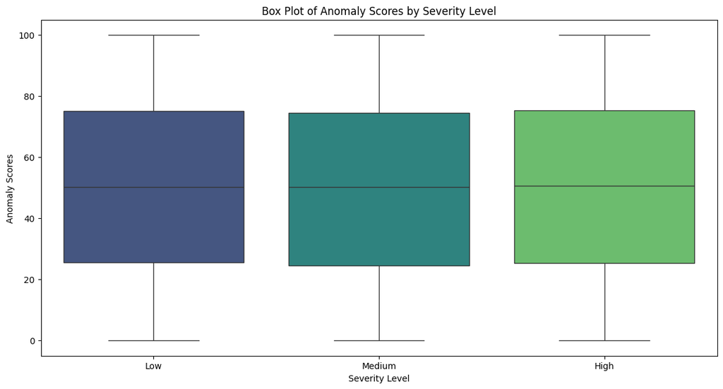

```python
plt.figure(figsize=(14, 7))
sns.boxplot(x='Severity Level', y='Anomaly Scores', data=df_cyberattacks, hue='Severity Level', legend=False, palette="viridis")
plt.title('Box Plot of Anomaly Scores by Severity Level')
plt.xlabel('Severity Level')
plt.ylabel('Anomaly Scores')
plt.show()
```

Let's look into the geo-location data:

```python
df_temp = df_cyberattacks.copy()
df_temp['State'] = df_temp['Geo-location Data'].str.split(', ').str[-1]
```

```python
unique_values = df_temp['State'].unique()
print(unique_values)
```

```
['Sikkim' 'Nagaland' 'Rajasthan' 'Tripura' 'Meghalaya' 'Manipur'
 'Andhra Pradesh' 'Mizoram' 'Haryana' 'Kerala' 'Odisha' 'Maharashtra'
 'Telangana' 'Uttarakhand' 'West Bengal' 'Gujarat' 'Chhattisgarh' 'Assam'
 'Madhya Pradesh' 'Karnataka' 'Goa' 'Tamil Nadu' 'Uttar Pradesh' 'Bihar'
 'Himachal Pradesh' 'Arunachal Pradesh' 'Jharkhand' 'Punjab']
```

From this, we know that our dataset only has Data for Indian states and Cities.

### Model Training and Evaluation:

```python
df_cyberattacks.head()
```

| Timestamp | Source IP Address | Destination IP Address | Source Port | Destination Port | Protocol | Packet Length | Packet Type | Traffic Type | Payload Data | Malware Indicators | Anomaly Scores | Alerts/Warnings | Attack Type | Attack Signature | Action Taken | Severity Level | User Information | Device Information | Network Segment | Geo-location Data | Proxy Information | Firewall Logs | IDS/IPS Alerts | Log Source | Day of Week | Hour | Year | Month |
| --- | --- | --- | --- | --- | --- | --- | --- | --- | --- | --- | --- | --- | --- | --- | --- | --- | --- | --- | --- | --- | --- | --- | --- | --- | --- | --- | --- | --- |
| 2023-05-30 06:33:58 | 103.216.15.12 | 84.9.164.252 | 31225 | 17616 | ICMP | 503 | Data | HTTP | Qui natus odio asperiores nam. Optio nobis ius... | IoC Detected | 28.67 | Not Triggered | Malware | Known Pattern B | Logged | Low | Reyansh Dugal | Mozilla/5.0 (compatible; MSIE 8.0; Windows NT ... | Segment A | Jamshedpur, Sikkim | 150.9.97.135 | Log Data | No Alert Data | Server | 1 | 6 | 2023 | 5 |
| 2020-08-26 07:08:30 | 78.199.217.198 | 66.191.137.154 | 17245 | 48166 | ICMP | 1174 | Data | HTTP | Aperiam quos modi officiis veritatis rem. Omni... | IoC Detected | 51.50 | Not Triggered | Malware | Known Pattern A | Blocked | Low | Sumer Rana | Mozilla/5.0 (compatible; MSIE 8.0; Windows NT ... | Segment B | Bilaspur, Nagaland | unknown | Log Data | No Alert Data | Firewall | 2 | 7 | 2020 | 8 |
| 2022-11-13 08:23:25 | 63.79.210.48 | 198.219.82.17 | 16811 | 53600 | UDP | 306 | Control | HTTP | Perferendis sapiente vitae soluta. Hic delectu... | IoC Detected | 87.42 | Triggered | DDoS | Known Pattern B | Ignored | Low | Himmat Karpe | Mozilla/5.0 (compatible; MSIE 9.0; Windows NT ... | Segment C | Bokaro, Rajasthan | 114.133.48.179 | Log Data | Alert Data | Firewall | 6 | 8 | 2022 | 11 |
| 2023-07-02 10:38:46 | 163.42.196.10 | 101.228.192.255 | 20018 | 32534 | UDP | 385 | Data | HTTP | Totam maxime beatae expedita explicabo porro l... | IoC not Detected | 15.79 | Triggered | Malware | Known Pattern B | Blocked | Medium | Fateh Kibe | Mozilla/5.0 (Macintosh; PPC Mac OS X 10_11_5; ... | Segment B | Jaunpur, Rajasthan | unknown | No Log Data | Alert Data | Firewall | 6 | 10 | 2023 | 7 |
| 2023-07-16 13:11:07 | 71.166.185.76 | 189.243.174.238 | 6131 | 26646 | TCP | 1462 | Data | DNS | Odit nesciunt dolorem nisi iste iusto. Animi v... | IoC not Detected | 0.52 | Triggered | DDoS | Known Pattern B | Blocked | Low | Dhanush Chad | Mozilla/5.0 (compatible; MSIE 5.0; Windows NT ... | Segment C | Anantapur, Tripura | 149.6.110.119 | No Log Data | Alert Data | Firewall | 6 | 13 | 2023 | 7 |

```python
categorical_features = ['Protocol', 'Packet Type', 'Traffic Type', 'Malware Indicators', 'Attack Type','Alerts/Warnings', 'Attack Signature', 'Network Segment', 'IDS/IPS Alerts', 'Log Source']
df = pd.get_dummies(df_cyberattacks, columns=categorical_features)

# Ordinal Encoding for ordinal features
ordinal_features = ['Severity Level']
ordinal_mappings = {
    'Severity Level': {'Low': 1, 'Medium': 2, 'High': 3},
}

for feature, mapping in ordinal_mappings.items():
    df[feature] = df[feature].map(mapping)
```

```python
df.head()
```

| Timestamp | Source IP Address | Destination IP Address | Source Port | Destination Port | Packet Length | Payload Data | Anomaly Scores | Action Taken | Severity Level | User Information | Device Information | Geo-location Data | Proxy Information | Firewall Logs | Day of Week | Hour | Year | Month | Protocol_ICMP | Protocol_TCP | Protocol_UDP | Packet Type_Control | Packet Type_Data | Traffic Type_DNS | Traffic Type_FTP | Traffic Type_HTTP | Malware Indicators_IoC Detected | Malware Indicators_IoC not Detected | Attack Type_DDoS | … |
| --- | --- | --- | --- | --- | --- | --- | --- | --- | --- | --- | --- | --- | --- | --- | --- | --- | --- | --- | --- | --- | --- | --- | --- | --- | --- | --- | --- | --- | --- | --- |
| 2023-05-30 06:33:58 | 103.216.15.12 | 84.9.164.252 | 31225 | 17616 | 503 | Qui natus odio asperiores nam. Optio nobis ius... | 28.67 | Logged | 1 | Reyansh Dugal | Mozilla/5.0 (compatible; MSIE 8.0; Windows NT ... | Jamshedpur, Sikkim | 150.9.97.135 | Log Data | 1 | 6 | 2023 | 5 | True | False | False | False | True | False | False | True | True | False | False | … |
| 2020-08-26 07:08:30 | 78.199.217.198 | 66.191.137.154 | 17245 | 48166 | 1174 | Aperiam quos modi officiis veritatis rem. Omni... | 51.50 | Blocked | 1 | Sumer Rana | Mozilla/5.0 (compatible; MSIE 8.0; Windows NT ... | Bilaspur, Nagaland | unknown | Log Data | 2 | 7 | 2020 | 8 | True | False | False | False | True | False | False | True | True | False | False | … |
| 2022-11-13 08:23:25 | 63.79.210.48 | 198.219.82.17 | 16811 | 53600 | 306 | Perferendis sapiente vitae soluta. Hic delectu... | 87.42 | Ignored | 1 | Himmat Karpe | Mozilla/5.0 (compatible; MSIE 9.0; Windows NT ... | Bokaro, Rajasthan | 114.133.48.179 | Log Data | 6 | 8 | 2022 | 11 | False | False | True | True | False | False | False | True | True | False | True | … |
| 2023-07-02 10:38:46 | 163.42.196.10 | 101.228.192.255 | 20018 | 32534 | 385 | Totam maxime beatae expedita explicabo porro l... | 15.79 | Blocked | 2 | Fateh Kibe | Mozilla/5.0 (Macintosh; PPC Mac OS X 10_11_5; ... | Jaunpur, Rajasthan | unknown | No Log Data | 6 | 10 | 2023 | 7 | False | False | True | False | True | False | False | True | False | True | False | … |
| 2023-07-16 13:11:07 | 71.166.185.76 | 189.243.174.238 | 6131 | 26646 | 1462 | Odit nesciunt dolorem nisi iste iusto. Animi v... | 0.52 | Blocked | 1 | Dhanush Chad | Mozilla/5.0 (compatible; MSIE 5.0; Windows NT ... | Anantapur, Tripura | 149.6.110.119 | No Log Data | 6 | 13 | 2023 | 7 | False | True | False | False | True | True | False | False | False | True | True | … |

```python
remove_cols = ['User Information', 'Device Information', 'Proxy Information', 'Source IP Address', 'Destination IP Address', 'Proxy Information', 'Action Taken', 'Source Port', 'Destination Port', 'Payload Data', 'Geo-location Data', 'Firewall Logs']
df = df.drop(columns=remove_cols)
```

[output not shown]

[output cut: 637 more lines]

[output not shown]

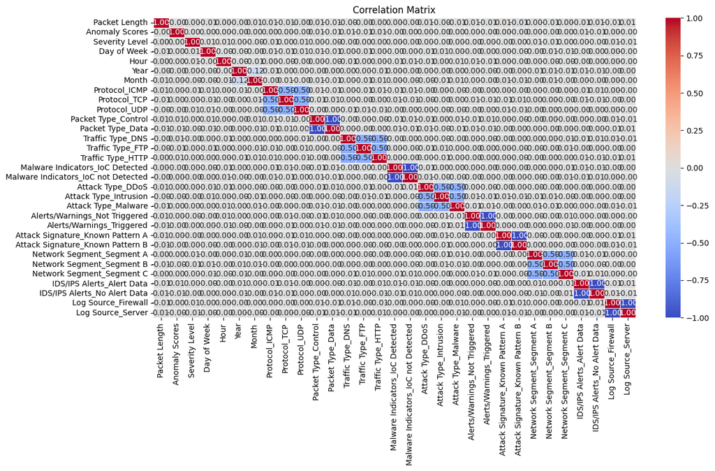

```python
numeric_columns = df.columns
correlation_matrix = df[numeric_columns].corr()

# Print the correlation matrix
print(correlation_matrix)

# Plot the correlation matrix
plt.figure(figsize=(14, 7))
sns.heatmap(correlation_matrix, annot=True, cmap='coolwarm', fmt='.2f', linewidths=.5)
plt.title('Correlation Matrix')
plt.show()
```

**Model Training and Testing:**

We will try to predict the severity level of attack so that if it's a medium or high severity attack, the alerts should be triggered and action can be taken to fix the vulnerability.

```python
X = df.drop('Severity Level', axis=1)
y = df['Severity Level']

# Split the dataset into training and testing sets
X_train, X_test, y_train, y_test = train_test_split(X, y, test_size=0.2, random_state=42)

# Initialize and train the classifier
clf = RandomForestClassifier(n_estimators=100, random_state=42)
clf.fit(X_train, y_train)

# Make predictions
y_pred = clf.predict(X_test)

# Evaluate the model
accuracy = accuracy_score(y_test, y_pred)
print(f'Accuracy: {accuracy}')
print('Classification Report:')
print(classification_report(y_test, y_pred))
```

```
Accuracy: 0.33975
Classification Report:
              precision    recall  f1-score   support

           1       0.36      0.35      0.35      2673
           2       0.34      0.34      0.34      2729
           3       0.32      0.33      0.33      2598

    accuracy                           0.34      8000
   macro avg       0.34      0.34      0.34      8000
weighted avg       0.34      0.34      0.34      8000
```

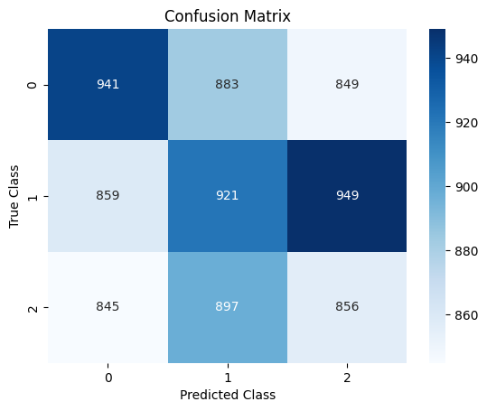

```python
import seaborn as sns

conf_matix = confusion_matrix(y_test, y_pred)

sns.heatmap(conf_matix, annot=True, fmt='d', cmap='Blues')

plt.xlabel('Predicted Class')
plt.ylabel('True Class')
plt.title('Confusion Matrix')
plt.show()
```

### Conclusion:

The model has given 34% accuracy on test data which is not really good.  
The reason for it is because the data we had did not have much variety to it. We need to find a better and clean dataset that can give us more accurate results on the testing data.